# Command Line, Git, & Python Basics

# Command Line

## [Command Line Experience](https://docs.google.com/forms/d/19is5DW07sVHBZZG4xdAjfGInpY6xQ3aqxZVzN-gQ7kM/edit#responses)

This is the text interface for telling your operating system what to do.

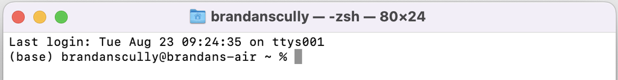

Commands are generally structured as

**[argument]** **[flags]** **[directory]**

# Current Directory Path

The **Full Path** or **Absolute Path** describes the complete hierarchy from the **Root Directory** to something.

The **Current Directory** is the directory your terminal is pointed to.

To get the **path** use pwd

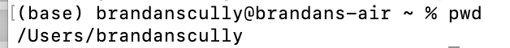

The **Root Directory** in this case is */Users*

# Changing Directories

To **c**hange **d**irectories, use **cd**

to go to a directory, **cd path**

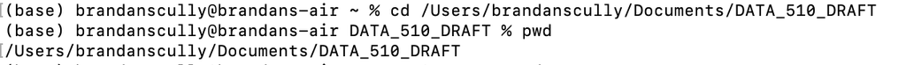

to go back one dircetory, **cd ..**

to go back two directories, **cd ../..**

to your home directory, **cd**

# Viewing the contents of a directory

to **l**ist files in a directory, use **ls**

to list them in descending order by size, add **-S**

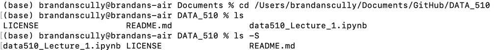

# Creaty empty things

to **make** a new empty **directory**, use **mkdir** *name*

```
% mkdir newFolder
```

to make a new empty file, use **touch** *name* (dot) *ext*

```
% touch someFile.txt
```

# Display file content

to show file content, use **cat** *name*

```
% cat someFile.txt
```

to **enumerate** file content, use **cat** **-n** *name*

```
% cat -n someFile.txt
```

to show only the **head** of a file to includ x lines, use **head** **-n x** *name*

```
% head -n 3 someFile.text
```

to show only the **tail** of a file to includ x lines, use **tail** **-n x** *name*

```
% tail -n 3 someFile.text
```

# Moving or Renaming or Both

you can **move** and/or **rename** a file with **mv**

to **move**, use **mv** *path* *newPath*

```
% mv someFile.txt /Users/brandanscully/Documents/Github/DATA_510
```

to **rename**, use **mv** *name* *newName*

```
% mv someFile.txt myFile.txt
```

to **move** *and* **rename**, use **mv** *path/name* *newPath/newName*

```
% mv someFile.txt /Users/brandanscully/Documents/Github/DATA_510/myFile.txt
```

# Removing files

to **remove** a file, use **rm** *path/name01* *multiple files *path/name02* *path/name03*

```
% rm someFile.txt  (BE CAREFUL!)
```

# Handy Cheat Sheet

https://fosswire.com/post/2007/08/unixlinux-command-cheat-sheet/

Seriously, just google command line cheat sheet for your enviornment. There are subtle differences between Mac, Windows, Linux.

# Version Control: Git & GitHub

## [Git/Github Experience](https://docs.google.com/forms/d/19is5DW07sVHBZZG4xdAjfGInpY6xQ3aqxZVzN-gQ7kM/edit#responses)

**Version control** allows one or multiple users to keep track of edits to a file(s).

**[Git](https://git-scm.com)** is an open source version control system.

- Very handy when you break things, because you can *rewind* to earlier (working) versions.
- Makes file sharing less cumbersome and less confusing than emailing attachments.
- Helpful to track progress because comments describe what was done and by whom with each commit.
- Provides the ability to require code review before implementation

**[GitHub](https://github.com)** is a popular implementation of Git.

# To Use Git

- Go to **[GitHub](https://github.com)**
- Sign up for GitHub with an email address.
- Download and install a Git GUI (I'm using *GitHub Desktop*)
- Here's a **[tutorial](https://docs.github.com/en/get-started/quickstart/hello-world)** from GitHub.

# Terms to know

**Repository** or **Repo** is a folder with Git implemented.

To **clone** a **repo** means to make a copy.

**Branch** is an alternative version of a *repo*.

**Commit** is a saved change to a version-controlled file. Normally you will add a comment describing the change.

# The DATA_510 course Repo

It's [here](https://github.com/brandanscully/DATA_510)!

# Python

## [Python Experience](https://docs.google.com/forms/d/19is5DW07sVHBZZG4xdAjfGInpY6xQ3aqxZVzN-gQ7kM/edit#responses)

[Python](https://www.python.org/) is an open-source object oriented computer programming language.

It's relatively easy to get started and very powerful once you become familiar with it.

I use [Anacondas](https://www.anaconda.com/products/distribution):

- It's free!
- It has most of the packages you need to do data science.
- It has some handy features, e.g. Jupyter Notebooks, Spyder IDE, conda package installer, & environment management.

Here are some [tutorials](https://docs.anaconda.com/anaconda/navigator/tutorials/) about Anacondas.

# Python Basics

Everything is an object.

**Modules** are repeatable pieces of code.

**Packages** are collections of modules.

Python works at the **command line**.

A **command** provides an instruction to the Python interpreter.

A **script** is a repeatable set of commands.

Here are some [tutorials](https://wiki.python.org/moin/BeginnersGuide/Programmers) about Pyton.

And here is the Python [documentation](https://docs.python.org/3/index.html)